# Avaliando e Visualizando a Diversidade Alfa, Beta e Filogenética

Minicurso Fitogeografia

##### Contexto

Gêneros grandes oferecem insights valiosos sobre a distribuição espacial da biodiversidade. *Mimosa* (Leguminosae), o grupo das dorme-dorme ou dormideiras, possui ≈ 600 espécies e está distribuído principalmente ao longo dos Neotrópicos, ocorrendo em diferentes biomas como savanas, florestas tropicais sazonalmente secas e florestas tropicais úmidas.

Nesta atividade prática, avaliaremos padrões de diversidade alfa e beta nos Neotrópicos usando *Mimosa* como grupo modelo e investigamos potenciais fatores que explicam a substituição (turnover) de espécies em diferentes escalas espaciais. Também calcularemos a diversidade filogenética ao longo de comunidades espaciais para incorporar a história evolutiva à investigação de padrões biogeográficos.

##### Dados

# 1. Começando

Primeiro, vamos limpar o ambiente removendo quaisquer objetos carregados anteriormente.

```r
rm(list = ls())
```

Em seguida, definimos nosso diretório de trabalho, que é a pasta contendo todos os dados necessários para este tutorial. Você pode fazer isso no RStudio indo em `Session -> Set Working Directory -> Choose Directory`, ou usando `setwd()` com o caminho como argumento.

Depois, vamos instalar e carregar os pacotes necessários para essa parte do tutorial. Instale quaisquer pacotes que você ainda não tenha usando `install.packages()` e observe possíveis erros de instalação. Recomenda-se usar a versão do R 4.4.1 ou superior. Ao longo deste tutorial, se você tiver dúvidas sobre como uma função específica funciona, use a função `help()` com o nome da função como argumento. Por exemplo, `help(rast)`.

```r
library(terra) # carregar e manipular dados espaciais
library(sf) # lidar com dados espaciais de forma conveniente como "simple features"
library(tidyverse) # compilação de pacotes de ciência de dados
library(data.table) # criar matriz de presença/ausência
library(betapart) # executar análise de diversidade beta
library(phangorn) # executar análise de agrupamento (clustering)
library(dendextend) # lidar com dendrogramas
library(viridis) # compilação de paletas
library(paletteer) # compilação de paletas
library(ggdendro) # lidar com dendrogramas usando ggplot2
library(gridExtra) # organizar gráficos na mesma saída
library(naturalsort) # ler arquivos *.tif na ordem correta
library(gdm) # avaliar potenciais fatores (drivers) da diversidade beta
```

# 2. Carregando e manipulando objetos espaciais

Dados espaciais são essenciais em análises de biodiversidade porque o espaço geográfico precisa ser representado com precisão. No R, usamos os pacotes `terra` e `sf` para trabalhar com dados espaciais. Aqui, vamos começar carregando um objeto espacial que representa as áreas terrestres globais.

```r
world <- vect("1.data/ne_countries_small/ne_countries_small.shp")
```

Agora, vamos inspecionar esse objeto.

```r
world
```

```
##  class       : SpatVector
##  geometry    : polygons
##  dimensions  : 177, 168  (geometries, attributes)
##  extent      : -180, 180, -90, 83.64513  (xmin, xmax, ymin, ymax)
##  source      : ne_countries_small.shp
##  coord. ref. : lon/lat WGS 84 (EPSG:4326)
##  names       :      featurecla scalerank labelrank      sovereignt sov_a3
##  type        :           <chr>     <int>     <int>           <chr>  <chr>
##  values      : Admin-0 country         1         6            Fiji    FJI
##                Admin-0 country         1         3 United Republi~    TZA
##                Admin-0 country         1         7  Western Sahara    SAH
##  adm0_dif level              type   tlc           admin (and 158 more)
##     <int> <int>             <chr> <chr>           <chr>
##         0     2 Sovereign country     1            Fiji
##         0     2 Sovereign country     1 United Republi~
##         0     2     Indeterminate     1  Western Sahara
```

Vamos visualizar o mapa:

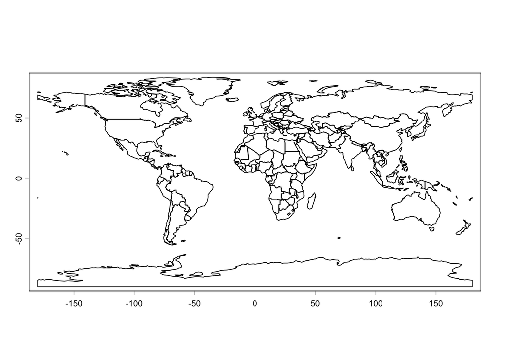

```r
plot(world)
```

## 2.1. Preparando células de grade

```r
# Ler o mesmo arquivo 'SpatVector' como 'sf', uma classe de objeto espacial mais flexível
# e conveniente para trabalhar no R
## Ocasionalmente, geometrias espaciais podem se tornar inválidas devido a auto-interseções
## ou linhas sobrepostas nos limites de polígonos. Aqui também corrigimos isso.
world_sf <- read_sf("1.data/ne_countries_small/ne_countries_small.shp")

# Remover o continente Antarctica
world_sf <- world_sf[world_sf$sovereignt != "Antarctica", ]

# Vamos cortar o mundo para um aproximado da distribuição de Mimosa, para optimizar as análises

# st_is_valid(world_sf)
#
# world_sf <- world_sf[world_sf$sovereignt != "Sudan", ]
#
# world_sf <- world_sf[world_sf$sovereignt != "Russia", ]
#
# st_is_valid(world_sf)
#
# box <- st_bbox(c(
#   xmin = -126,
#   xmax = 160,
#   ymin = -60,
#   ymax = 45
# ), crs = st_crs(world_sf))
#
# box <- st_as_sfc(box)
#
# plot(st_geometry(world_sf))
# plot(box, add = TRUE, border = "red", lwd = 2)
#
# world_sf <- st_crop(world_sf, box)
#
# plot(st_geometry(world_sf))

# Reprojetar o objeto espacial para EPSG:3857 (Web Mercator)
world_sf <- st_transform(world_sf, crs = 3395)

# Criar células de grade hexagonais cobrindo a extensão espacial do globo e
# adiciona um ID para cada célula da grade
hex_grid_sf <- st_make_grid(world_sf, cellsize = 100000, square = F) %>%
  st_sf(.) %>%
  mutate(grid_id = 1:nrow(.))

# Identificar as células da grade que realmente se sobrepõem aos continentes, criando um
# vetor binário (0 = sem interseção; 1 = intersecta)
is_intersecting <- hex_grid_sf %>%
  st_intersects(., world_sf) %>%
  sapply(., function(x) if(length(x) == 0) 0 else 1)

# Manter apenas as células da grade que intersectam os continentes
hex_grid_world <- hex_grid_sf[which(is_intersecting == 1), ]
```

Vamos visualizar o globo dividido em células hexagonais.

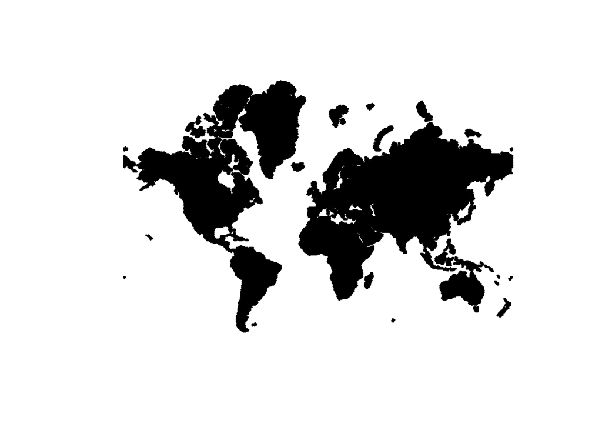

```r
plot(st_geometry(hex_grid_world))
```

# Pergunta 1:

Quantas células de grade criamos? *Dica*: A estrutura de um objeto `sf` é semelhante à de um data frame. Cada geometria é uma linha associada a múltiplos atributos.

# 3. Carregando e manipulando dados de ocorrência georreferenciados

Dados de ocorrência georreferenciados fornecem informações precisas sobre as localizações das espécies, o que os torna ideais para análises espaciais de biodiversidade. Nesta seção, carregamos os dados globais de ocorrência de espécies de *Mimosa* e os preparamos criando uma matriz de presença/ausência baseada em células de grade, permitindo visualizar a distribuição de espécies em unidades espaciais.

```r
occurrence <- read.csv("1.data/occurrence_clean.csv")
```

Vamos inspecionar a estrutura dos dados de ocorrência.

```r
str(occurrence)
```

```
## 'data.frame':    69760 obs. of  22 variables:
##  $ record_id             : int  6714 6820 6850 7160 7163 7372 7384 7398 7443 7452 ...
##  $ source                : chr  "gbif" "gbif" "gbif" "gbif" ...
##  $ institution_code      : chr  "PRC" "PRC" "PRC" "PRC" ...
##  $ collection_code       : chr  "TEX" "TEX" "TEX" "TEX" ...
##  $ catalog_number        : chr  "295546" "230099" "295664" "230215" ...
##  $ genus                 : chr  "Mimosa" "Mimosa" "Mimosa" "Mimosa" ...
##  $ species               : chr  "borealis" "asperata" "roemeriana" "conzattii" ...
##  $ infraspecific         : chr  NA NA NA NA ...
##  $ full_name_clean       : chr  "Mimosa_borealis" "Mimosa_pigra_asperata" "Mimosa_quadrivalvis_platycarpa" "Mimosa_tricephala_xanti" ...
##  $ full_name_clean_sp_lvl: chr  "Mimosa_borealis" "Mimosa_pigra" "Mimosa_quadrivalvis" "Mimosa_tricephala" ...
##  $ basis_of_record       : chr  "PRESERVED_SPECIMEN" "PRESERVED_SPECIMEN" "PRESERVED_SPECIMEN" "PRESERVED_SPECIMEN" ...
##  $ identified_by         : chr  "Turner, Billie Lee" "Turner, Billie Lee" "Turner, Billie Lee" "Morton, C. V." ...
##  $ collector             : chr  "Fred A. Barkley;Sgt. Julius Cohn" "Juan Ismael Calzada" "Roger W. Sanders" "Robert Merrill King" ...
##  $ collector_number      : chr  NA NA NA NA ...
##  $ year_collected        : chr  "1943" "1974" "1995" "1959" ...
##  $ country               : chr  "US" "MX" "US" "MX" ...
##  $ state_province        : chr  "Texas" "Veracruz" "Texas" "Oaxaca" ...
##  $ county                : chr  "Travis" "Catemaco" "Hunt" NA ...
##  $ municipality          : chr  NA NA NA NA ...
##  $ locality              : chr  "Limestone outcrop 3 miles northwest of Austin." "Las cabañas a 5 km al N de la desv de la carr que va al Jicacal" "Clymer Meadow Preserve, ca. 15 airmiles northwest of Greenville; along county road ca. 1/2 mile (1 kn) north of"| __truncated__ "2-4 Km E of Tehuante…
##  $ longitude             : num  -97.8 -95.1 -96.2 -95.2 -98.2 ...
##  $ latitude              : num  30.3 18.6 33.3 16.3 30.3 ...
```

# Pergunta 2:

Quantos registros o conjunto de dados de ocorrência contém? A que esses registros se referem? *Dica*: verifique o atributo `basis_of_record`.

O conjunto de dados contém 22 atributos, como o nome da espécie, o nome do coletor e do determinador, informações relacionadas à localidade, ano de coleta e, mais importante, longitude e latitude. Usaremos estes últimos para converter o conjunto de dados em um objeto espacial.

```r
# Converter o data frame de ocorrências em um objeto sf usando o CRS WGS84,
# que é o padrão para dispositivos GPS, e depois reprojete o objeto utilizando
# o CRS das células da grade
occurrence_points <- st_as_sf(x = occurrence,
                              coords = c("longitude", "latitude"),
                              crs = "EPSG:4326") %>%
  st_transform(., crs(hex_grid_world))
```

Agora, com isso em mãos, vamos intersectar os pontos espaciais de ocorrência (registros) com as células de grade e recuperar o ID da célula de grade para cada registro.

```r
# Intersectar ocorrências com as células da grade para identificar quais
# registros estão dentro de cada célula da grade.
inter_occurrence <- st_intersects(occurrence_points, hex_grid_world)

# Atribuir cada registro de ocorrência a uma célula da grade com base no
# resultado da interseção.
occurrence_points$grid_id <- NA
for(j in 1:nrow(occurrence_points)){
  if(length(inter_occurrence[[j]]) == 1){
    occurrence_points$grid_id[j] <- hex_grid_world$grid_id[inter_occurrence[[j]]]
  }
}

# Filtrar os dados de ocorrência para manter apenas os registros que se
# encontram dentro da área de estudo (neste caso, todos os continentes)
occurrence$grid_id <- occurrence_points$grid_id
occurrence <- occurrence %>%
  filter(!is.na(grid_id))
```

Então, podemos criar uma matriz de comunidades de presença/ausência (0 = ausência; 1 = presença), com células de grade nas linhas e espécies nas colunas. Isso servirá como entrada para as análises espaciais subsequentes de biodiversidade.

```r
# Criar uma matriz de comunidade com presença/ausência de espécies em cada
# célula da grade
comm_matrix <- dcast(as.data.table(occurrence),
                     grid_id ~ full_name_clean_sp_lvl,
                     fun.aggregate = length)
comm_matrix <- as.data.frame(comm_matrix)
rownames(comm_matrix) <- comm_matrix$grid_id
comm_matrix <- comm_matrix[ , -1]           # Remove a coluna grid_id
comm_matrix[comm_matrix > 1] <- 1           # Converte valores >1 em 1 para
                                            # dados de presença/ausência
```

# 4. Calculando a diversidade alfa como riqueza de espécies

A riqueza de espécies é a forma mais simples de calcular a diversidade alfa. Para isso, basta contar o número de espécies por célula de grade.

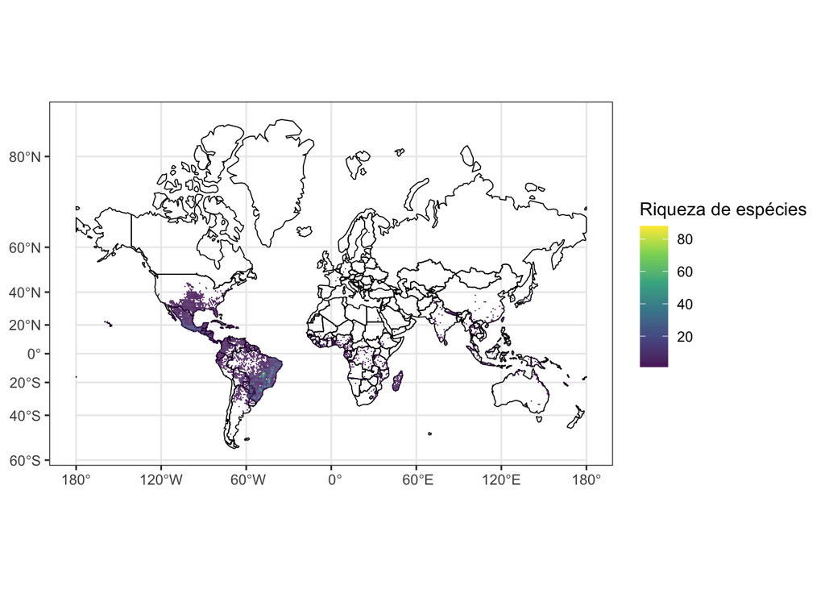

```r
# Somar o número de espécies por célula da grade
sp_richness <- rowSums(comm_matrix)

# Armazenar os valores de riqueza de espécies em cada célula da grade
hex_grid_world <- hex_grid_world %>%
  mutate(sp_richness = sp_richness[as.character(grid_id)])

# Plotar a riqueza de espécies
sr <- ggplot() +
  geom_sf(data = world_sf,
          aes(), color = "black", fill = "transparent",
          lwd = 0.3) +
  geom_sf(data = hex_grid_world,
          aes(fill = sp_richness),
          color = "transparent",
          lwd = 0) +
  scale_fill_continuous(type = "viridis",
                        na.value = NA,
                        alpha = 0.9,
                        name = "Riqueza de espécies") +
  theme_bw() +
  theme(legend.position = "right")
sr
```

# Pergunta 3:

O que você pode dizer sobre a riqueza de espécies de *Mimosa* na América do Sul?

# 5. Calculando a diversidade beta

Antes de prosseguir, vamos preparar nossa matriz de comunidades para as análises de diversidade beta. Singletons — espécies encontradas em apenas uma amostra — podem introduzir ruído ao inflar a dissimilaridade entre comunidades e obscurecer padrões espaciais na composição de espécies. Da mesma forma, células com apenas uma espécie podem ter o mesmo efeito. Para lidar com isso, removeremos tanto os singletons quanto as células de grade contendo uma única espécie. O código abaixo itera esse processo até que essas condições sejam atendidas.

```r
# Remover (1) células da grade com número de espécies abaixo do limiar definido e
# (2) espécies únicas (isto é, que ocorrem em menos de duas células)
threshold <- 2

### Repetir os passos 1 e 2 em um loop
repeat{
  # Identificar células e espécies a serem removidas
  cells_to_rm <- which(rowSums(comm_matrix) < threshold)
  sp_to_rm <- which(colSums(comm_matrix) < threshold)

  # Interromper o loop se nenhuma linha ou coluna atender mais ao critério de remoção
  if (length(cells_to_rm) == 0 && length(sp_to_rm) == 0) {
    break
  }

  # Remover as células e espécies identificadas
  if (length(cells_to_rm) > 0) {
    comm_matrix <- comm_matrix[-cells_to_rm, , drop = FALSE]
  }
  if (length(sp_to_rm) > 0) {
    comm_matrix <- comm_matrix[, -sp_to_rm, drop = FALSE]
  }
}
```

Agora vamos executar uma análise multi-sítio de diversidade beta para inspecionar a heterogeneidade geral na composição de espécies entre nossas amostras e verificar qual componente da diversidade beta é o mais influente.

```r
beta_multi <- beta.multi(x = comm_matrix,
                         index.family = "jaccard")
beta_multi
```

```
## $beta.JTU
## [1] 0.9988424
##
## $beta.JNE
## [1] 0.0006072048
##
## $beta.JAC
## [1] 0.9994496
```

Considerando que um valor de 1 implica dissimilaridade máxima, a diversidade beta total (`beta.JAC`) é muito alta (>0.99) para nossas amostras. Como o componente de aninhamento (`beta.JNE`) é muito baixo (0.001), focaremos no componente de substituição (`beta.JTU`) nos passos seguintes.

Em seguida, realizaremos uma análise pareada de diversidade beta para calcular a diversidade beta e seus componentes entre cada par possível de amostras, armazenando os resultados em uma matriz de distâncias.

```r
beta_pair <- beta.pair(x = comm_matrix,
                       index.family = "jaccard")
```

Usando essa matriz de distâncias, conduziremos uma análise de agrupamento para visualizar relações entre amostras tanto em um mapa quanto em um dendrograma. Existem vários algoritmos disponíveis para agrupar elementos com base em sua similaridade. Aqui, usaremos o algoritmo de Ward, que geralmente apresenta bom desempenho no contexto de diversidade beta.

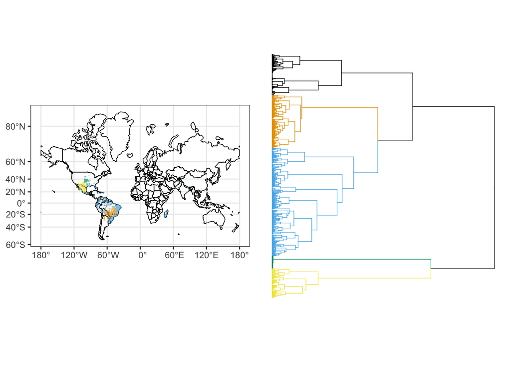

```r
# Executar uma análise de agrupamento usando o algoritmo de Ward para o componente de turnover
set.seed(1)
jtu_cluster <- upgma(beta_pair$beta.jtu, method = "ward.D")
jtu_hc <- as.hclust(jtu_cluster)

# Criar um dendrograma
jtu_dend <- as.dendrogram(jtu_hc)

# Dividir o dendrograma em clusters e atribuir uma cor diferente a cada um deles
## Aqui, dividimos arbitrariamente o dendrograma em 5 clusters. Em última análise,
## o número de clusters depende da pergunta de pesquisa, mas geralmente é melhor
## relatar os resultados com diferentes números de clusters.
ncluster <- 5
colors <- as.character(paletteer_d("ggthemes::colorblind"))[1:ncluster]
jtu_dend <- color_branches(jtu_dend, k = ncluster,
                            col = colors) %>%
  set("branches_lwd", c(0.25))

# Criar um gráfico do dendrograma
dend <- as.ggdend(jtu_dend)
dend <- ggplot(dend, labels = FALSE) +
  scale_x_reverse(expand = c(0.2, 0)) + # Inverter o eixo x para que as pontas
                                        # fiquem voltadas para a esquerda
  coord_flip()                          # Rotacionar o gráfico para orientação horizontal
# Obter o ID do cluster e a cor para cada célula da grade
grid_id_cluster <- data.frame("grid_id" = labels(jtu_dend),
                              "colour" = get_leaves_branches_col(
                                jtu_dend
                              ),
                              "cluster_membership" = NA)
colors_2 <- colors
names(colors_2) <- as.character(1:length(colors_2))
for(i in 1:nrow(grid_id_cluster)){
  grid_id_cluster$cluster_membership[i] <-
    names(colors_2)[unname(colors_2) == grid_id_cluster$colour[i]]
}

# Codificar os IDs dos clusters como fatores
grid_id_cluster$cluster_membership <-
  factor(grid_id_cluster$cluster_membership,
         levels = unique(grid_id_cluster$cluster_membership))

# Mesclar os dados espaciais com os IDs e cores dos clusters
jtu_sf <- merge(hex_grid_world, grid_id_cluster, by.x = "grid_id",
                 all.x = TRUE, all.y = TRUE)

# Criar o mapa
map <- ggplot() +
  geom_sf(data = world_sf,
          aes(), color = "black", fill = "transparent",
          lwd = 0.3)  +
  geom_sf(data = jtu_sf,
          aes(fill = cluster_membership),
          color = "transparent",
          lwd = 0) +
  scale_fill_manual(values = adjustcolor(colors, alpha = 0.9),
                    na.value = NA)+
  theme_bw() +
  theme(legend.position = "none")

# Plotar o mapa e o dendrograma lado a lado
grid.arrange(map, dend, ncol = 2)
```

O mapa e o dendrograma funcionam juntos para ilustrar similaridades na composição de espécies entre células de grade. Cada terminal (folha) no dendrograma representa uma célula de grade, e o agrupamento reflete similaridades composicionais entre as células. Células da mesma cor no mapa são mais semelhantes em composição do que aquelas com cores diferentes. Além disso, o dendrograma mostra relações entre os grupos de células, e podemos interpretá-lo de forma semelhante a como interpretamos uma árvore filogenética. Por exemplo, células amarelas e verdes são mais semelhantes entre si do que em relação a quaisquer outras células.

# Pergunta 4:

O que você pode deduzir a partir do mapa e do dendrograma? Que padrões emergiram?

# 6. Avaliando os determinantes da substituição espacial usando GDM

Até agora, avaliamos *como* as espécies estão distribuídas no espaço usando diversidade alfa (riqueza de espécies) e diversidade beta (dissimilaridade de Jaccard). No entanto, entender *por que* a composição de espécies muda no espaço é igualmente ou ainda mais importante, pois pode revelar insights sobre padrões e processos ecológicos. Nesta seção, examinaremos os determinantes da substituição espacial para espécies de *Mimosa*, com foco em variáveis relacionadas à temperatura e precipitação baixadas do [WorldClim](https://worldclim.org/data/worldclim21.html) e variáveis relacionadas ao solo baixadas do [SoilGrids](https://soilgrids.org). Para isso, aplicaremos a Modelagem de Dissimilaridade Generalizada (GDM), que modela distâncias composicionais pareadas entre locais como função de potenciais preditores.

Vamos começar carregando essas variáveis abióticas no nosso ambiente.

```r
# Carregar variáveis do BioClim
bioclim_list <-
  naturalsort(list.files("1.data/bioclim_mercator",
                         pattern =".tif$", full.names = TRUE))
bioclim_rasters <- rast(bioclim_list)
## Mudar nomes do BioClim
lookup <- read.csv("lookup_table.csv")
names(bioclim_rasters) <- lookup$variable_name_snake_case[1:19]

# Carregar variáveis do Soil World
soil_list <- list.files("1.data/soil_world_mercator",
                        pattern = ".tif$", full.names = TRUE)
soil_rasters <- rast(soil_list)
## Mudar nomes do Soil World
names(soil_rasters) <- lookup$variable_name_snake_case[20:26]
```

As variáveis estão armazenadas como rasters com resolução de 30 segundos, o que é incompatível com as unidades espaciais que definimos para nossas análises. Felizmente, podemos resolver esse problema aplicando estatísticas zonais para atribuir as variáveis a cada uma das nossas células de grade. Usando essa abordagem, calcularemos médias ponderadas para cada célula de grade com base na proporção de interseção com os rasters.

Devido ao tempo de processamento dessa etapa (horas), o código foi comentado (#) e já disponibilizamos o resultado como um arquivo rds.

```r
# z_stats_bioclim <- terra::zonal(bioclim_rasters,
#                                 vect(hex_grid_world),
#                                 na.rm = TRUE,
#                                 w = NULL,
#                                 weights = TRUE,
#                                 exact = TRUE,
#                                 touches = TRUE,
#                                 as.raster = FALSE)
# z_stats_soil <- terra::zonal(soil_rasters,
#                              vect(hex_grid_world),
#                              na.rm = TRUE,
#                              w = NULL,
#                              weights = TRUE,
#                              exact = TRUE,
#                              touches = TRUE,
#                              as.raster = FALSE)
# z_stats <- cbind(z_stats_bioclim, z_stats_soil)

# saveRDS(z_stats, file = "zonal_statistics.rds")

z_stats <- readRDS("zonal_statistics.rds")
```

Usaremos estatísticas zonais para preparar uma matriz local-por-preditor, que servirá como entrada para o GDM

```r
# Obter as coordenadas do centróide de cada célula da grade (importante para calcular
# distâncias geográficas posteriormente)
grid_coords <- crds(centroids(vect(hex_grid_world)))

# Preparar a matriz sítio-por-preditor
site_predictor <- data.frame("grid_id" = hex_grid_world$grid_id,
                             "lon" = grid_coords[ , 1],
                             "lat" = grid_coords[ , 2])
site_predictor <- cbind(site_predictor,
                        z_stats)

# Atribuir valores abióticos para cada célula da grade no objeto espacial
grid_cells <- cbind(hex_grid_world, site_predictor)
```

Agora vamos rodar o GDM e examinar os resultados. As saídas principais são a porcentagem de desvio explicada e a soma dos coeficientes para cada variável. A porcentagem de desvio explicada indica quanta variação na dissimilaridade da comunidade é explicada pelos preditores, enquanto a soma dos coeficientes para cada variável mostra a contribuição de cada variável para essa explicação (com somas maiores indicando maior contribuição explicativa). Aqui, também adicionamos distância geográfica como um preditor putativo para substituição de espécies no espaço com `geo = TRUE`.

```r
# Remover NAs da matriz sítio-por-preditor e corresponder com a matriz de comunidade
site_predictor <- site_predictor %>%
  filter(complete.cases(.) & grid_id %in% rownames(comm_matrix))

# Obter uma tabela de pares de sítios (entrada do GDM)
biodata_1 <- comm_matrix %>%
  as.data.frame(.) %>%
  mutate(grid_id = as.numeric(rownames(.))) %>%
  relocate(., grid_id) %>%
  filter(grid_id %in% site_predictor$grid_id)

gdm_tab <- formatsitepair(bioData = biodata_1,
                          bioFormat = 1,
                          siteColumn = "grid_id",
                          predData = site_predictor,
                          XColumn = "lon",
                          YColumn = "lat",
                          dist = "jaccard",
                          weightType = "richness")

# Executar o GDM
gdm_model <- gdm(gdm_tab, geo = TRUE)
summary(gdm_model)
```

```
## [1]
## [1]
## [1] GDM Modelling Summary
## [1] Creation Date:  Mon Jun 22 16:38:02 2026
## [1]
## [1] Name:  gdm_model
## [1]
## [1] Data:  gdm_tab
## [1]
## [1] Samples:  1853775
## [1]
## [1] Geographical distance used in model fitting?  TRUE
## [1]
## [1] NULL Deviance:  19824.273
## [1] GDM Deviance:  13521.047
```

[output cut: 275 more lines]

Podemos particionar o modelo usando `gdm.partition.deviance()` para avaliar quanto cada categoria de variável (clima, solo, espaço) contribui para o desvio explicado.

```r
# Particionar 2 grupos de variáveis
## Criar uma lista de conjuntos de variáveis para o particionamento
varSet <- vector("list", 2)

# Nomear os grupos de variáveis para o particionamento
# Dois grupos (clima e solo)
names(varSet) <- c("climate", "soil")

# Adicionar os nomes das variáveis
varSet$soil <- names(soil_rasters)
varSet$climate <- names(bioclim_rasters)

# Executar a função para particionar solo, clima e espaço (partSpace = TRUE)
scgPart <- gdm.partition.deviance(gdm_tab, varSet, partSpace = TRUE)
scgPart
```

```
##                            VARIABLE_SET DEVIANCE
## 2                               climate    25.88
## 3                                  soil    16.43
## 1                                   geo    16.93
## 4                        climate & soil    28.32
## 5                         geo & climate    30.66
## 6                            geo & soil    24.06
## 7  ALL VARIABLES (geo & climate & soil)    31.80
## 8                           UNEXPLAINED    68.20
## 9                         climate alone     7.74
## 10                           soil alone     1.14
## 11                            geo alone     3.47
## 12  climate intersect soil, exclude geo     5.99
## 13  climate intersect geo, exclude soil     4.15
## 14  geo intersect soil, exclude climate     1.30
## 15 soil intersect climate intersect geo     8.00
```

# Pergunta 5:

Quais são os 5 determinantes mais importantes da diversidade beta, de acordo com o nosso modelo? *Dica*: verifique a soma dos coeficientes.

Se você tiver curiosidade sobre como uma determinada variável abiótica está distribuída na área de estudo, tente plotá-la. No exemplo abaixo, plotamos a precipitação anual. Use sua resposta da pergunta acima para explorar visualmente a distribuição dos determinantes mais importantes da diversidade beta. Você consegue ajustar os parâmetros do código por conta própria? *Dica*: procure o nome da variável.

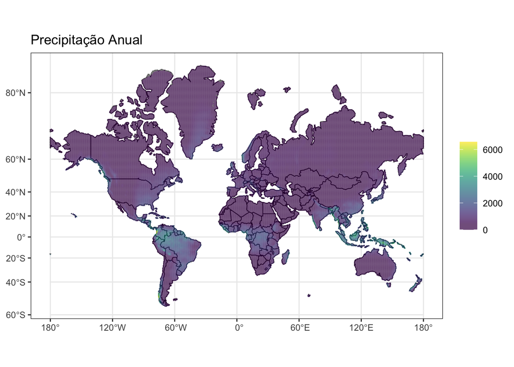

```r
ggplot() +
  geom_sf(data = world_sf,
          color = "black",
          lwd = 0.3) +
  geom_sf(data = grid_cells,
          aes(fill = annual_precipitation),
          color = "transparent",
          lwd = 0) +
  scale_fill_gradient(low = adjustcolor(viridis(1), alpha.f = 0.7),
                      high = adjustcolor(viridis(16), alpha.f = 0.7)) +
  ggtitle("Precipitação Anual") +
  labs(fill = NULL,
       colour = NULL) +
  theme_bw()
```

# 7. Investigando padrões de biodiversidade utilizando diversidade filogenética (PD)

Até o momento, consideramos apenas estimativas de biodiversidade que não levam em conta a história evolutiva das espécies. No entando, podemos também avaliar o quão diversas são as áreas de estudo em termos de linhagens usando métricas de diversidade filogenética.

Vamos carregar os pacotes para essa segunda parte do tutorial.

```r
library(phytools)
```

```r
library(ape)
library(ggplot2)
library(beepr)
library(remotes)
library(picante)
library(viridis)
library(sf)

#BiocManager::install("ggtree")
#remotes::install_github("YuLab-SMU/ggtree", force = TRUE) #alternartiva
library(ggtree)
```

Agora, vamos carregar e visualizar a árvore filogenética de *Mimosa*.

```r
tree <- read.tree("1.data/tree-Vasconcelos2020.txt")

# Inpecionando o objeto árvore
tree$tip.label #taxa presentes na árvore
```

```
##   [1] "Mimosa_longepedunculata"           "Mimosa_oedoclada"
##   [3] "Mimosa_setosissima"                "Mimosa_foliolosa_brevibractea"
##   [5] "Mimosa_densa_alligantina"          "Mimosa_claussenii_prorsiseta"
##   [7] "Mimosa_manidea"                    "Mimosa_ulei_grallator"
##   [9] "Mimosa_foliolosa_paranani"         "Mimosa_vernicosa_ciliata"
##  [11] "Mimosa_lithoreas"                  "Mimosa_rheiptera"
##  [13] "Mimosa_decorticans"                "Mimosa_ulei_ulei"
##  [15] "Mimosa_rhodostegia"                "Mimosa_tocantina"
##  [17] "Mimosa_nitens"                     "Mimosa_foliolosa_pubescens"
##  [19] "Mimosa_stylosa"                    "Mimosa_splendida"
##  [21] "Mimosa_viperina"                   "Mimosa_foliolosa_gravida"
##  [23] "Mimosa_pachycarpoides"             "Mimosa_heringeri"
##  [25] "Mimosa_cryptothamnos"              "Mimosa_claussenii_microphyllidia"
##  [27] "Mimosa_claussenii_megistophylla"   "Mimosa_foliolosa_multipinna"
##  [29] "Mimosa_foliolosa_peregrina"        "Mimosa_melanocarpa"
```

[output cut: 181 more lines]

```r
tree$Nnode #número de nós
```

```
## [1] 390
```

```r
max(nodeHeights(tree)) # valor total da altura de todos os nós
```

```
## [1] 27.4962
```

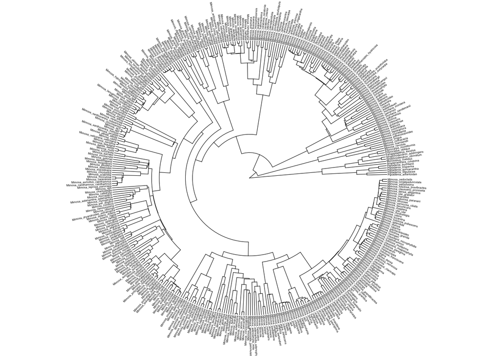

```r
# Plotando a árvore
ggtree(tree, size = 0.2, layout = "circular") +
  geom_tiplab(size = 1)
```

A árvore possui taxa além de *Mimosa* (grupos externos). Uma vez que só temos os dados de distribuição de espécies de *Mimosa*, precisamos remover os grupos externos para as análises subsequentes.

```r
outgroup <- c(tree$tip.label[!grepl("Mimosa", tree$tip.label)])

outgroup
```

```
##  [1] "Pityrocarpa_obliqua"         "Pityrocarpa_moniliformis"
##  [3] "Parapiptadenia_excelsa"      "Stryphnodendron_obovatum"
##  [5] "Stryphnodendron_adstringens" "Microlobius_foetidus"
##  [7] "Anadenanthera_colubrina"     "Piptadenia_trisperma"
##  [9] "Piptadenia_buchtienii"       "Piptadenia_gonoacantha"
## [11] "Piptadenia_adiantoides"      "Piptadenia_stipulacea"
```

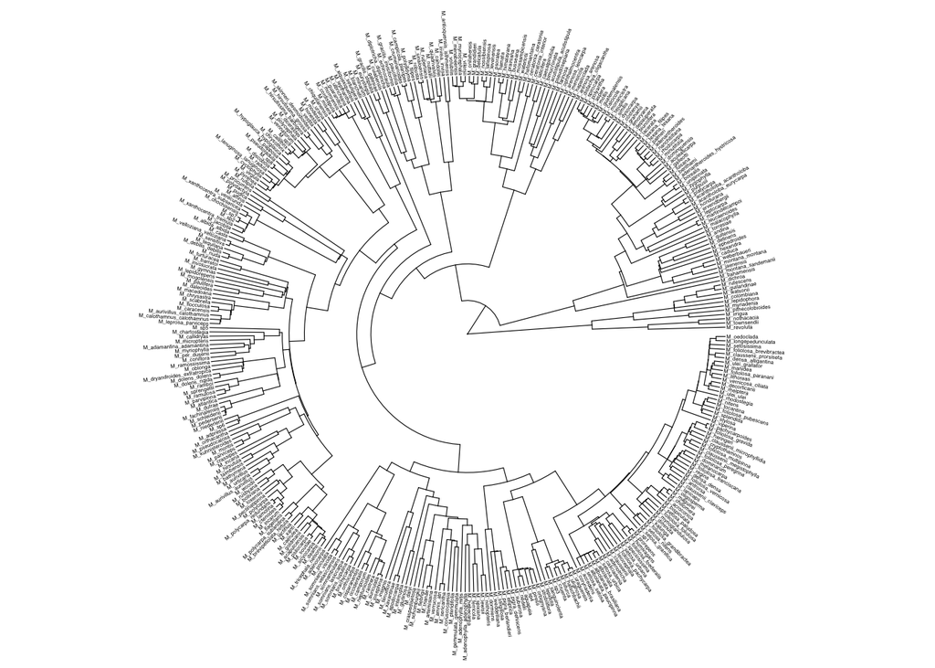

```r
pruned_tree <- drop.tip(tree, outgroup)

#plotando a árvore podada
ggtree(pruned_tree, size = 0.2, layout = "circular") +
  geom_tiplab(aes(label = sub("Mimosa", "M", label)),
              size=1)
```

Além disso, precisamos também ajustar a nossa matriz de comunidades para conter apenas as espécies presentes na filogenia.

```r
colnames(comm_matrix)[colnames(comm_matrix) %in% tree$tip.label] # espécies que estão no banco de dados de ocorrência e na filogenia
```

```
##   [1] "Mimosa_acapulcensis"     "Mimosa_accedens"
##   [3] "Mimosa_acroconica"       "Mimosa_aculeaticarpa"
##   [5] "Mimosa_adenantheroides"  "Mimosa_adenocarpa"
##   [7] "Mimosa_adenotricha"      "Mimosa_adpressa"
##   [9] "Mimosa_affinis"          "Mimosa_aguapeia"
##  [11] "Mimosa_albolanata"       "Mimosa_andina"
##  [13] "Mimosa_antrorsa"         "Mimosa_apodocarpa"
##  [15] "Mimosa_atlantica"        "Mimosa_auriculata"
##  [17] "Mimosa_aurivillus"       "Mimosa_bahamensis"
##  [19] "Mimosa_barretoi"         "Mimosa_bifurca"
##  [21] "Mimosa_bimucronata"      "Mimosa_bispiculata"
##  [23] "Mimosa_biuncifera"       "Mimosa_blanchetii"
##  [25] "Mimosa_boliviana"        "Mimosa_borealis"
##  [27] "Mimosa_brachycarpa"      "Mimosa_caduca"
##  [29] "Mimosa_caerulea"         "Mimosa_caesalpiniifolia"
```

[output cut: 112 more lines]

```r
# Podando a matrix de presença-ausência para conter apenas especies que ocorrem na filogenia
comm_matrix_phyl <- comm_matrix[ , colnames(comm_matrix) %in%
                                   pruned_tree$tip.label]
```

Agora que temos a hipótese filogenética e matriz de presença e ausência ajustada, podemos calcular a diversidade filogenética para cada comunidade (células de grade).

Devido ao tempo de processamento dessa etapa, o código foi comentado (#) e já disponibilizamos o resultado como um arquivo rds.

```r
# set.seed(42)
# pd_stats <- ses.pd(comm_matrix_phyl, pruned_tree,
#                    include.root = TRUE,
#                    null.model = "taxa.label")
#
# saveRDS(pd_stats, file = "phylogenetic_diversity_stats.rds")

pd_stats <- readRDS("phylogenetic_diversity_stats.rds")

# atribuindo id
pd_stats$id <- rownames(pd_stats)
pd_stats$id <- as.numeric(pd_stats$id)
# intersect(grid_cells$grid_id, pd_stats$id)

# estimando resíduos da relação entre diversidade filogenética e riqueza de taxa
pd_stats$residuals <- lm(pd.obs ~ ntaxa, pd_stats)$res

# Arredondando valores
cols_to_round <- names(pd_stats)[!names(pd_stats) %in%
                                   c("ntaxa", "pd.obs.p", "id")]

pd_stats[,cols_to_round] <- round(pd_stats[,cols_to_round], 2)

# Combinando resultados de pd com objeto espacial
pd_poly <- dplyr::left_join(grid_cells, pd_stats,
                            by = c("grid_id" = "id"))

# extensão das grids para os plots
st_bbox(grid_cells)
```

```
##      xmin      ymin      xmax      ymax
## -20137508  -7503973  20112492  18505657
```

```r
# Para melhorar a visualização, cortaremos o mapa para focar em regiões com padrões mais evidententes
lat60 <- st_coordinates(
  st_transform(
    st_sfc(st_point(c(60, 60)), crs = 4326),
    3395
  )
)

#Plot de dievrsidade filogenética (pd.obs)
ggplot() +
  geom_sf(
    data = world_sf,
    color = "black",
    fill = "transparent",
    lwd = 0.3
  ) +
  geom_sf(
    data = pd_poly,
    aes(fill = pd.obs),
    color = "transparent",
    lwd = 0,
    alpha = 0.9
  ) +
  scale_fill_viridis_c(
    option = "magma",
    direction = -1,
    na.value = NA,
    name = "Div. filogenética"
  ) +
  coord_sf(
    xlim = c(-20137508, lat60[1]),
    ylim = c(-7503973, lat60[2])
  ) +
  theme_bw() +
  theme(
    legend.position = "right"
  ) -> pd_plot

#Plot de riqueza de taxa (ntaxa)
ggplot() +
  geom_sf(
    data = world_sf,
    color = "black",
    fill = "transparent",
    lwd = 0.3
  ) +
  geom_sf(
    data = pd_poly,
    aes(fill = ntaxa),
    color = "transparent",
    lwd = 0,
    alpha = 0.9
  ) +
  scale_fill_viridis_c(
    option = "magma",
    direction = -1,
    na.value = NA,
    name = "Riqueza"
  ) +
  coord_sf(
    xlim = c(-20137508, lat60[1]),
    ylim = c(-7503973, lat60[2])
  ) +
  theme_bw() +
  theme(
    legend.position = "right"
  ) -> sr_plot

# Plot dos resíduos da regressão lineaer entre diversidade filogenética e riqueza de taxa
ggplot() +
  geom_sf(
    data = world_sf,
    color = "black",
    fill = "transparent",
    lwd = 0.3
  ) +
  geom_sf(
    data = pd_poly,
    aes(fill = residuals),
    color = "transparent",
    lwd = 0,
    alpha = 0.9
  ) +
  scale_fill_viridis_c(
    option = "magma",
    direction = -1,
    na.value = NA,
    name = "Resíduos"
  ) +
  coord_sf(
    xlim = c(-20137508, lat60[1]),
    ylim = c(-7503973, lat60[2])
  ) +
  theme_bw() +
  theme(
    legend.position = "right"
  ) -> res_plot
```

# Pergunta 6: